# Chapter 7 Lab: Non-linear Modeling

### Splines

A spline is a piece-wise polynomial with pieces defined by a sequence of knots
$$\eta_1
<\eta_2<\cdots<\eta_k$$
such that the pieces join smoothly at the knots.

The simplest case is a linear spline with one knot $\eta_1$
$$S(x)=\beta_0+\beta_1 x +\gamma (
x-\eta_1)_{+}$$
term $( x - \eta_1)_{+}$ is 0 until $x$ is larger than $\eta_1$.

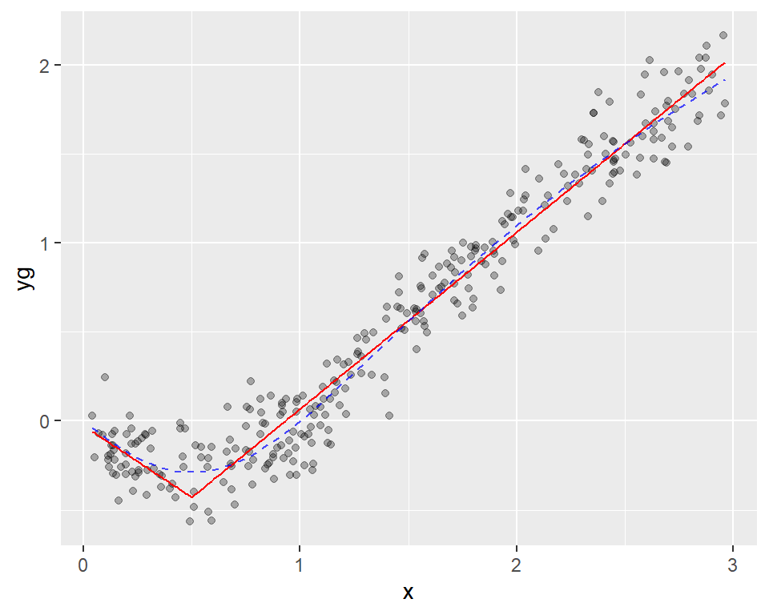

For a spline of degree $m$ one usually requires the polynomials and their first $m - 1$ derivatives to agree at the knots, so that $m - 1$ derivatives are continuous. A spline of degree $m$ can be represented as a power series:

$$S(x)=\sum^m_{j=0}\beta_0
x^j+\sum^k_{j=1}\gamma_j(x-\eta_j)^{m}_{+}$$

The most popular splines are cubic splines:
$$S(x)= \beta_0
+\beta_1x+\beta_2x^2+\beta_3x^3+\sum^k_{j=1}\gamma_j(x-\eta_j)^3_{+}$$

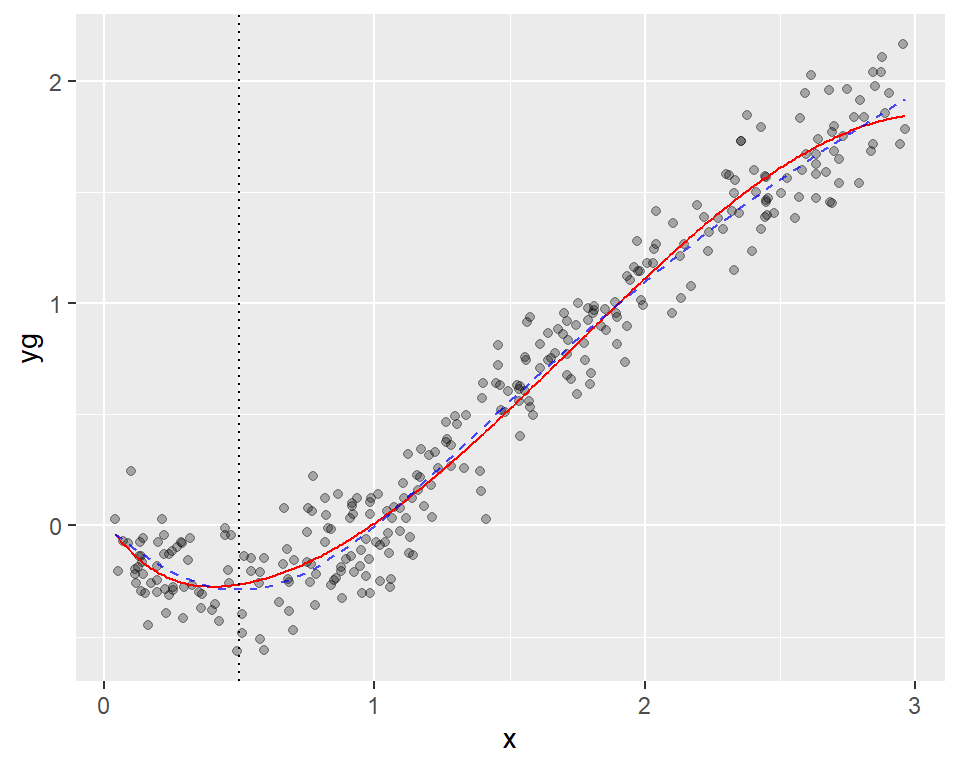

#### Interpolating Splines

Suppose we know the values of a function at $k$ points $x_1 < \dots < x_k$ and would like to interpolate for other $x$’s. If we used a spline of degree $m$ with knots at the observed $x$’s, we would have $m + 1 + k$ parameters to estimate with only $k$ observations. Obviously, we need some restrictions.

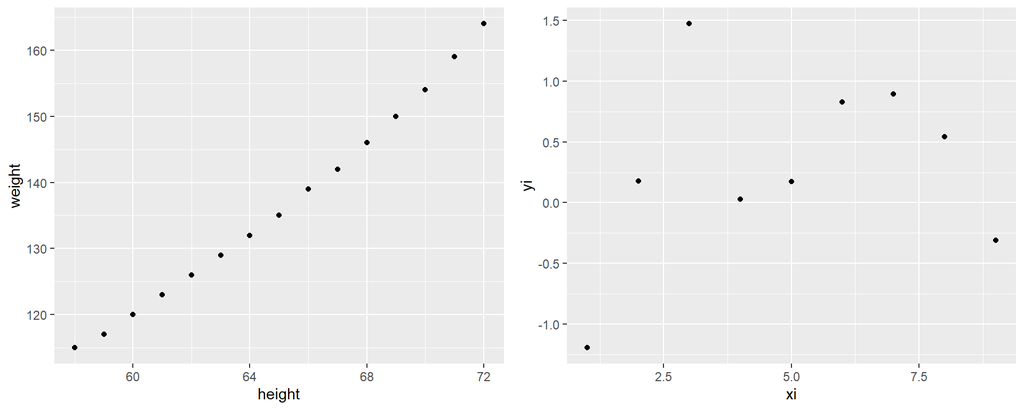

```r
gridExtra::grid.arrange(
ggplot(women)+aes(x=height,y=weight)+geom_point(),
ggplot(data.frame(xi,yi))+aes(x=xi,y=yi)+geom_point()
,ncol=2)
```

#### Natural Splines

A spline of odd degree $m = 2\nu-1$ is called a natural spline if it is a polynomial of degree $\nu - 1$ outside the range of the knots (i.e. below $\eta_1$ or above $\eta_k$). A natural cubic spline ($\nu=2$) is linear outside the range of the data. For a natural spline,
$$\begin{eqnarray*}
\beta_j &=& 0 \mbox{ for } j=\nu,\dots,2\nu-1 \\
\sum^k_{i=1}\gamma_i\eta_i^j &=&0 \mbox{ for }
j=0,1,\dots,\nu-1.
\end{eqnarray*}$$

This imposes exactly $m + 1$ restrictions, so we have $k$ parameters left. Note that a natural cubic spline has the form

$$S(x)=\beta_0 +\beta_1 x+
\sum^k_{j=1}\gamma_j(x-\eta_j)^3_{+}$$
, subject to the restrictions $\sum \gamma_j =0$ and $\sum \gamma_j\eta_j =0$ so we end up with $k$ parameters.

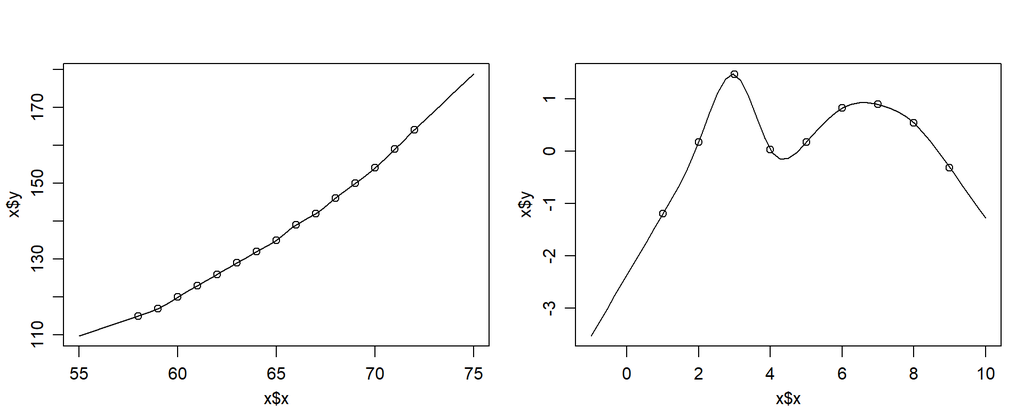

```r
library(splines)
require(graphics); require(stats)
ispl  <- interpSpline( women$height, women$weight ,bSpline=TRUE)
ispl2 <- interpSpline( weight ~ height,  women ,bSpline=TRUE)
# ispl and ispl2 should be the same
par(mfrow = c(1,2), mgp = c(2,.8,0), mar = 0.1+c(3,3,3,1))

#par(mfrow=c(1,2))
plot( predict( ispl, seq( 55, 75, length.out = 51 ) ), type = "l" )
points( women$height, women$weight )
#plot( ispl )    # plots over the range of the knots
#points( women$height, women$weight )
#splineKnots( ispl )

ispl2 <- interpSpline( yi ~ xi ,bSpline=TRUE)
plot(predict( ispl2, seq( -1, 10, length.out = 51 ) ), type = "l")
points(xi,yi)
```

#### Spline Regression

Consider now the problem of smoothing a scatterplot.

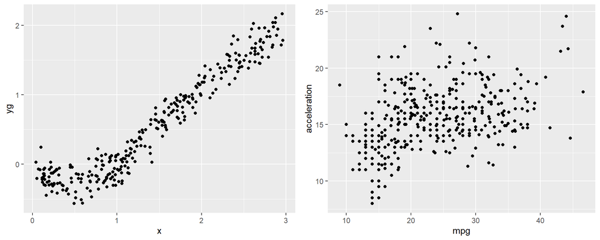

```r
gridExtra::grid.arrange(
ggplot(dt)+aes(x=x,y=yg)+geom_point(),
ggplot(Auto)+aes(x=mpg,y=acceleration)+geom_point()
,ncol=2)
```

One approach is to select s suitable set of knots with $k << n$ and then fit a spline by OLS (or WLS, or maximum likelihood).

For a cubic spline, this amounts to regressing $y$ on $k + 4$ predictors, namely $1,x,x_2,x_3,(x-\eta_1)^3_{+},(x-\eta_2)^3_{+},...,(x-\eta_k)^3_{+}$ For a natural cubic spline, we would drop $x^2$ and $x^3$ and impose the additional constraints
$$\sum\gamma = \sum \gamma\eta = 0.$$
Actually, these constraints can be eliminated by suitable re-parametrization. For example, a natural cubic spline with two interior knots plus one knot at each extreme of the data can be fit by regressing $y$ on three covariates, $x$, $z_1$, and $z_2$, where and
$$z_1 = ( x - \eta_1 )^3_{+} -\frac{ ( \eta_1 -
\eta_4 )} {(\eta_3 - \eta_4)} ( x - \eta_3 )^3_{+}$$
$$z_2 = ( x - \eta_2 )^3_{+} -\frac{( \eta_2 -
\eta_4 )} {(\eta_3 - \eta_4)}( x - \eta_3 )^3_{+} .$$

#### B-Splines

A much better representation of splines for computation is as linear combinations of a set of basis splines called B-splines. These are numerically more stable, among other reasons, because each B-spline is non-zero over a limited range of knots. They are not so easy to calculate, but fortunately, R and S have functions for calculating a basis, see bs for B-splines and ns for natural B-splines. Regression splines are very popular because they are easy to use, and can be incorporated without difficulty as part of other estimation procedures. The main problem is where to place the knots. Often, they are placed at selected percentiles. A smarter strategy would place more knots in regions where $f(x)$ is changing more rapidly. Knot placement is an arcane art form and the first disadvantage cited by detractors of regression splines.

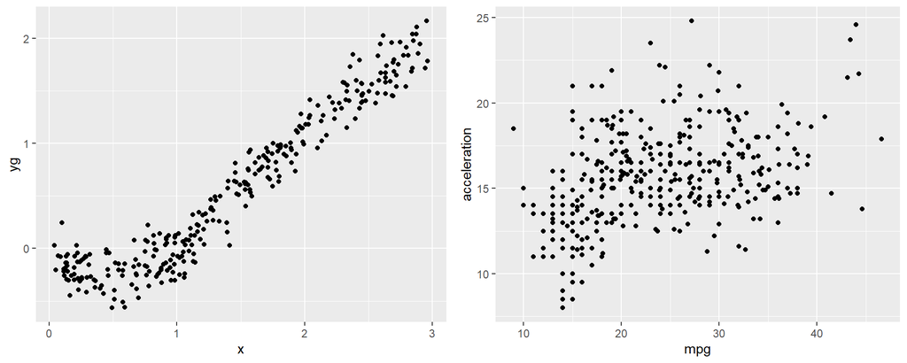

```r
gridExtra::grid.arrange(
ggplot(dt)+aes(x=x,y=yg)+geom_point(),
ggplot(Auto)+aes(x=mpg,y=acceleration)+geom_point()
,ncol=2)
```

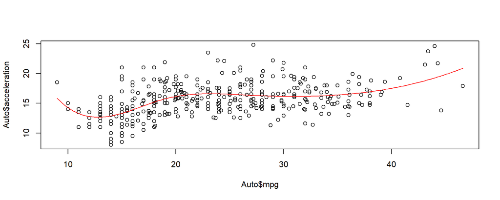

```r
xxmpg=seq(9,46.6,by=0.1)
predac=predict(lm(acceleration~bs(mpg,df=5),data=Auto),
                   newdata=data.frame(mpg=xxmpg))
plot(Auto$mpg,Auto$acceleration)
lines(xxmpg,predac,col="red")
```

#### Smoothing Splines

A more formal approach to the problem is to consider fitting a spline with knots at every data point. It could fit perfectly but estimate its parameters by minimizing the usual sum of squares plus a roughness penalty. A suitable penalty is to integrate the squared second derivative, leading to the following criterion, known as the penalized sum of squares:

$$PSS = (y_i-S(x_i))^2 +
\lambda(S''(x))^2dx$$

where integration is over the range of x, and $\lambda$ is a tuning parameter. As $\lambda\rightarrow 0$ we impose no penalty and end up with a very close fit, but the resulting curve could be very noisy as it follows every detail in the data. As $\lambda\rightarrow \infty$ the penalty dominates, the solution converges to the OLS line, which is as smooth as you can get (the second derivative is always 0) but may be a very poor fit. Amazingly, it can be shown that minimizing the PSS for a fixed $\lambda$ over the space of all continuous differentiable functions leads to a unique solution, and this solution is a natural cubic spline with knots at the data points. More generally, penalizing the squared v-th derivative leads to a natural spline of degree $2\nu-1$. For proof, see Reinsch (1967).

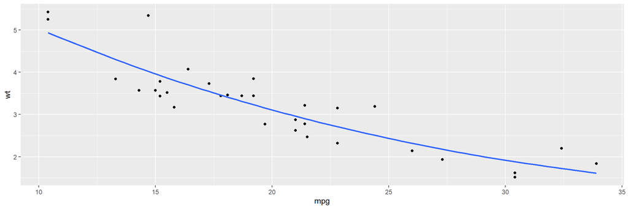

```r
smooth.spline2 <- function(formula, data, ...) {
  mat <- model.frame(formula, data)
  smooth.spline(mat[, 2], mat[, 1])
}

predictdf.smooth.spline <- function(model, xseq, se, level) {
  pred <- predict(model, xseq)
  data.frame(x = xseq, y = pred$y)
}

qplot(mpg, wt, data = mtcars) + geom_smooth(method = "smooth.spline2", se= F)
```

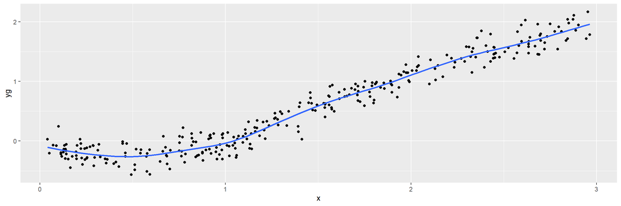

```r
qplot(x, yg, data = dt) + geom_smooth(method = "smooth.spline2", se= F)
```

#### Cross-Validation We have solved the problem of knot placement, but now we have to pick an appropriate value for $\lambda$. Some claim this is easier because we are left with a single number to worry about. Wabba and others have suggested a technique known as cross-validation. Let $S_{\lambda}(-i)$ denote the spline fit with tuning parameter $\lambda$ while omitting the i-th observation. We can compare this fit with the observed value $y_i$, and we can summarize these differences by computing a sum of squares
$$CVSS(\lambda) = \sum_{i=1}^{n}
(y_i-\hat{S}_{\lambda} (x_i))^2$$
which depends on $\lambda$. The idea is to pick $\lambda$ to minimize the $CVSS(\lambda)$. This sounds like a lot of work but it isn’t, thanks again to regression updating formulas, which can be used to show that
$$CVSS(\lambda) =
\sum_{i=1}^{n} \frac{(y_i - \hat{S}_{\lambda} (x_i))^2}{ 1 -
A_{ii}}$$

where $A_{ii}$ is a diagonal element of $A = (I - \lambda K)-1$. This extends easily to WLS. An alternative criterion is to replace the Aii with their average, which is $tr(A)/n$. This leads to a generalized CVSS that has been found to work well in practice.

### basis function plotting

Basis functions are mysterious, but it’s pretty neat once you get what bs and ns are doing.

#### linear

```r
fit1=lm(wage~bs(age,degree=1,knots=c(25,40,60)),data=Wage)
bs.weight1<-fit1$coefficients[-1]/sum(fit1$coefficients[-1])
bs.age1<-with(Wage,bs(age,degree=1,knots=c(25,40,60)))
xage=seq(18,80,by=1)
pred.bs.age1<- predict(bs.age1,newx=xage)
```

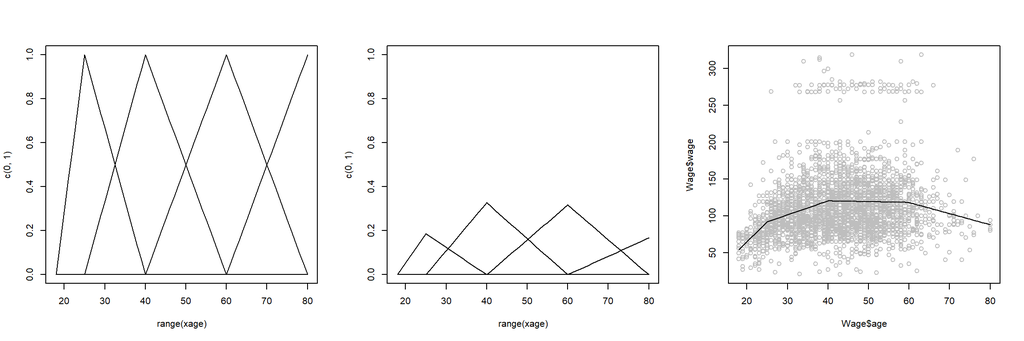

```r
par(mfrow=c(1,3))
plot(range(xage),c(0,1),type="n")
for(i in 1:4) lines(xage,pred.bs.age1[,i])
plot(range(xage),c(0,1),type="n")
for(i in 1:4) lines(xage,bs.weight1[i]*pred.bs.age1[,i])
plot(Wage$age,Wage$wage,col="gray")
lines(xage,fit1$coefficients[1]+pred.bs.age1%*%fit1$coefficients[-1],type="l")
```

#### quadratic

```r
fit2=lm(wage~bs(age,degree=2,knots=c(25,40,60)),data=Wage)
bs.weight2<-fit2$coefficients[-1]/sum(fit2$coefficients[-1])
bs.age2<-with(Wage,bs(age,degree=2,knots=c(25,40,60)))
xage=seq(18,80,by=1)
pred.bs.age2<- predict(bs.age2,newx=xage)
```

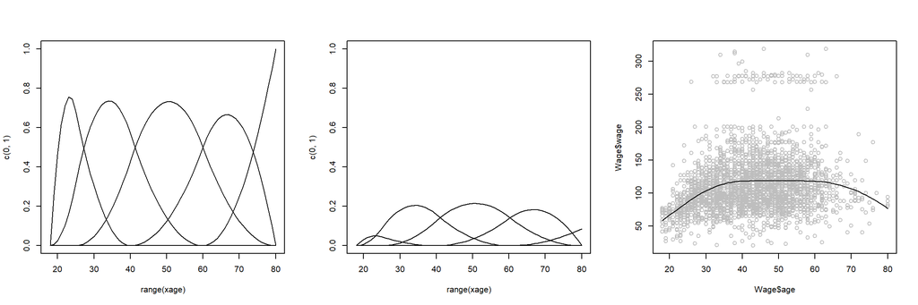

```r
par(mfrow=c(1,3))
plot(range(xage),c(0,1),type="n")
for(i in 1:5) lines(xage,pred.bs.age2[,i])
plot(range(xage),c(0,1),type="n")
for(i in 1:5) lines(xage,bs.weight2[i]*pred.bs.age2[,i])
plot(Wage$age,Wage$wage,col="gray")
lines(xage,fit2$coefficients[1]+pred.bs.age2%*%fit2$coefficients[-1],type="l")
```

#### cubic

```r
fit3=lm(wage~bs(age,knots=c(25,40,60)),data=Wage)
bs.age<-with(Wage,bs(age,knots=c(25,40,60)))
xage=seq(18,80,by=1)
pred.bs.age<- predict(bs.age,newx=xage)
```

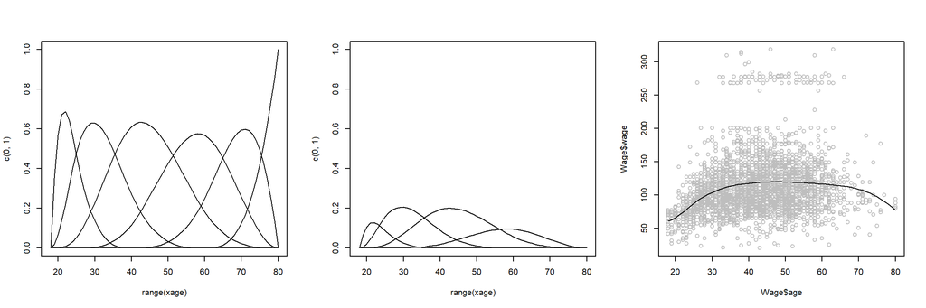

```r
par(mfrow=c(1,3))
plot(range(xage),c(0,1),type="n")
for(i in 1:6) lines(xage,pred.bs.age[,i])
plot(range(xage),c(0,1),type="n")
for(i in 1:6) lines(xage,bs.weight1[i]*pred.bs.age[,i])
plot(Wage$age,Wage$wage,col="gray")
lines(xage,fit3$coefficients[1]+pred.bs.age%*%fit3$coefficients[-1],type="l")
```

### Manually drawing the interval

If you want to draw confidence and prediction intervals, using the R predict function is the easiest thing to do.

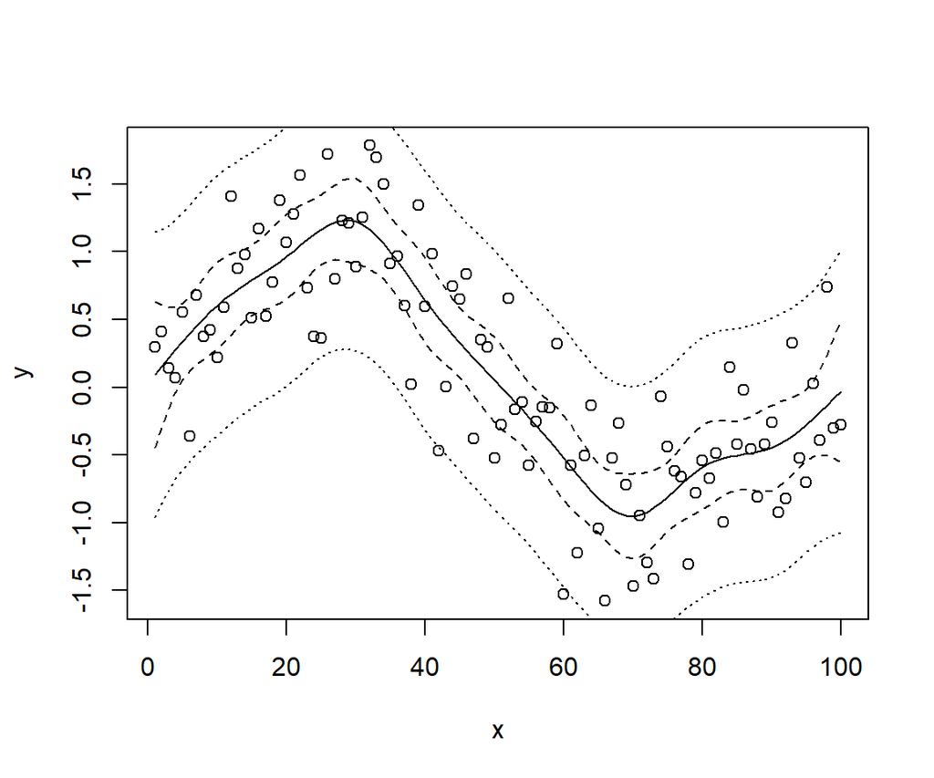

```r
# create random data
set.seed(12345)
x <- c(1:100)
y <- sin(pi*x/50)+rnorm(100,0,0.4)
epsilon <- rnorm(100, 0, 3)
knots <- c(10, 20, 30, 40, 50, 60, 70, 80, 90)

# Fit a natural spline
myFit <- lm(y ~ ns(x, knots = knots))

# Plot the result
plot(x,y)
lines(x,predict(myFit))
# Confidence interval
lines(x,predict(myFit,interval="confidence")[,"upr"],lty=2)
lines(x,predict(myFit,interval="confidence")[,"lwr"],lty=2)
# Prediction interval
lines(x,predict(myFit,interval="prediction")[,"upr"],lty=3)
lines(x,predict(myFit,interval="prediction")[,"lwr"],lty=3)
```

```r
# How the point-wise standard error is created
# One way is to grab the model matrix from the fitted object
X        <- model.matrix(myFit)
sigma    <- summary(myFit)$sigma
var.Yhat <- (diag(X %*% solve(t(X) %*% X) %*% t(X))) * sigma^2
mean(predict(myFit,se.fit = TRUE)$se.fit-sqrt(var.Yhat) )
```

```
## [1] -6.494805e-17
```

```r
# Another option is to call ns function
ppe      <-predict(myFit,interval="confidence",se.fit = TRUE)
X.new    <- cbind(1, ns(c(50:150), knots=knots))
var.Yhat <- (diag(X.new %*% solve(t(X) %*% X) %*% t(X.new)) + 1) * sigma^2
mean(predict(myFit,newdata =data.frame(x= c(50:150)),se.fit = TRUE)$se.fit-sqrt(var.Yhat) )
```

```
## [1] 0.3340086
```

### using mgcv gam

There are two popular packages for fitting GAM in R.

- `gam`
- `mgcv`

The authors of the book like `gam`. But `mgcv` is better at doing some things because they are Bayesian. The key difference is that `gam` uses smoothing spline whereas `mgcv` uses p-spline. Also, the uncertainty interval is Bayesian for `mgcv`, which tends to be better calibrated.

#### kyphosis example (gam)

84 Children at the Toronto Hospital for Sick Children underwent Laminectomy, a corrective spinal surgery for a variety of abnormalities under the general heading kyphosis. Results: 65 successes, 19 kyphosis still present. Goal: Try to understand/predict whether the operation will be successful

```r
data(kyphosis,  package = "gam")
```

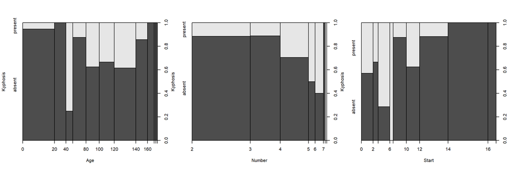

```r
detach("package:gam", unload=TRUE)
library(mgcv)

layout(matrix(1:3, nrow = 1))
spineplot(Kyphosis ~ Age, data = kyphosis,
           ylevels = c("present", "absent"))
spineplot(Kyphosis ~ Number, data = kyphosis,
           ylevels = c("present", "absent"))
spineplot(Kyphosis ~ Start, data = kyphosis,
          ylevels = c("present", "absent"))
```

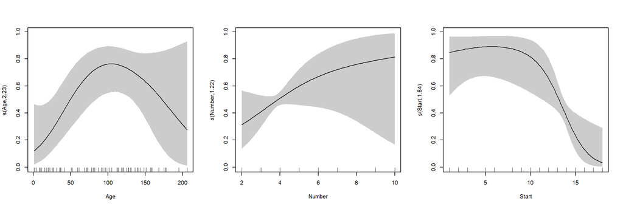

```r
kyphosis_gam <- gam(Kyphosis ~ s(Age, bs = "cr") +
      s(Number, bs = "cr", k = 3) + s(Start, bs = "cr", k = 3),
      family = binomial, data = kyphosis)

trans <- function(x)
      binomial()$linkinv(x)

layout(matrix(1:3, nrow = 1))
plot(kyphosis_gam, select = 1, shade = TRUE, trans = trans )
plot(kyphosis_gam, select = 2, shade = TRUE, trans = trans )
plot(kyphosis_gam, select = 3, shade = TRUE, trans = trans )
```

### Other Examples

#### Air pollution example (HSAUR2)

Air pollution data of 41 US cities. The annual mean concentration of sulfur dioxide, in micrograms per cubic meter, is a measure of the city’s air pollution. The question of interest here is what aspects of climate and human ecology, as measured by the other six variables in the data, determine pollution?

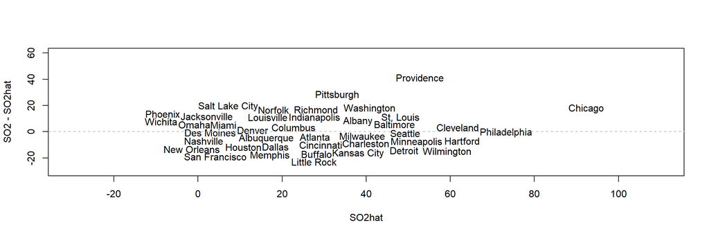

```r
library(mgcv)
data(USairpollution,  package = "HSAUR2")

USairpollution_gam <- gam(SO2 ~ s(wind, bs = "cr") +
      s(log(temp), bs = "cr", k = 3) + s(log(precip), bs = "cr", k = 3)+ s(log(popul), bs = "cr", k = 3)
      + s(log(manu), bs = "cr", k = 3)+ s(log(predays), bs = "cr", k = 3),data = USairpollution)

SO2hat <- predict(USairpollution_gam)
SO2 <- USairpollution$SO2
plot(SO2hat, SO2 - SO2hat, type = "n",
     xlim = c(-30, 110), ylim = c(-30, 60))
textplot(SO2hat, SO2 - SO2hat, rownames(USairpollution),
         show.lines = FALSE, new = FALSE)
abline(h = 0, lty = 2, col = "grey")
```

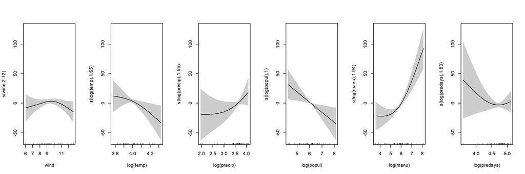

```r
layout(matrix(1:6, nrow = 1))
plot(USairpollution_gam, select = 1, shade = TRUE )
plot(USairpollution_gam, select = 2, shade = TRUE )
plot(USairpollution_gam, select = 3, shade = TRUE )
plot(USairpollution_gam, select = 4, shade = TRUE )
plot(USairpollution_gam, select = 5, shade = TRUE )
plot(USairpollution_gam, select = 6, shade = TRUE )
```